# 시각화

##### `geom_bar()` 함수 이용

- xlab,ylab : x,y축 이름 설정
- ggtitle : 제목 설정

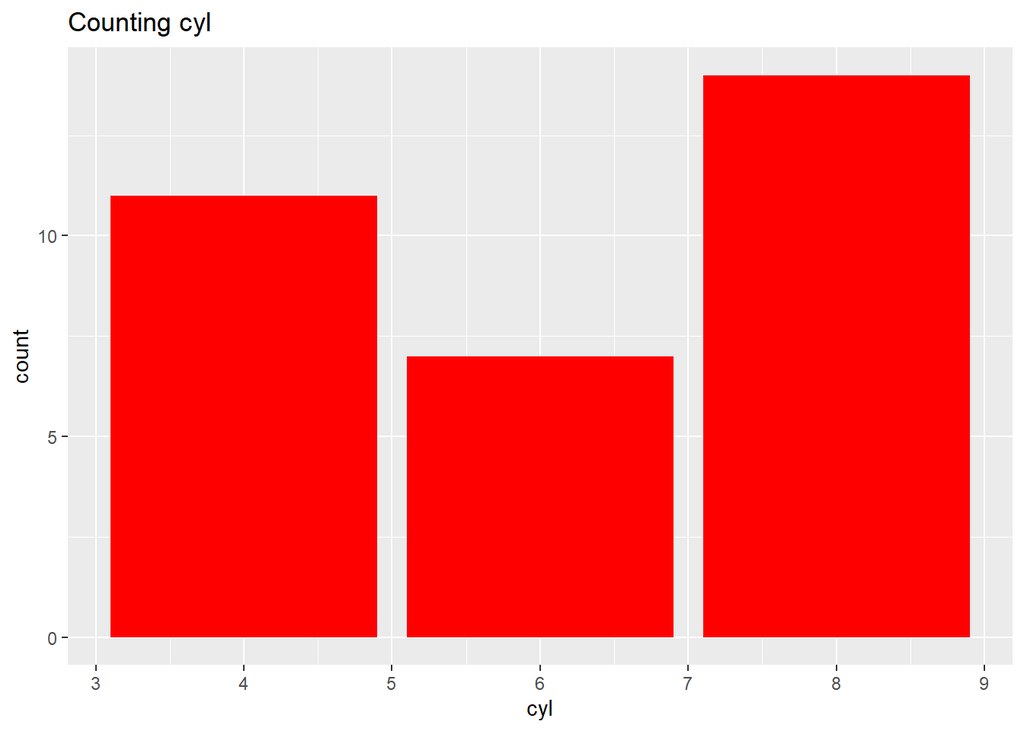

```r
ggplot(mtcars, aes(x = cyl, fill = am)) +
  geom_bar(fill = "red") +
  xlab("cyl") +
  ylab("count") +
  ggtitle("Counting cyl")
```

##### `scale_fill_brewer()` 함수 이용

- scale_fill_brewer을 사용하여 100%를 기준, fill 그룹으로 나누어 색깔의 짙은 정도로 bar 그래프를 그려줌

```r
library(car)
Vocab$education <- as.factor(Vocab$education)
Vocab$vocabulary <- as.factor(Vocab$vocabulary)
head(Vocab)
```

```
##          year    sex education vocabulary
## 19740001 1974   Male        14          9
## 19740002 1974   Male        16          9
## 19740003 1974 Female        10          9
## 19740004 1974 Female        10          5
## 19740005 1974 Female        12          8
## 19740006 1974   Male        16          8
```

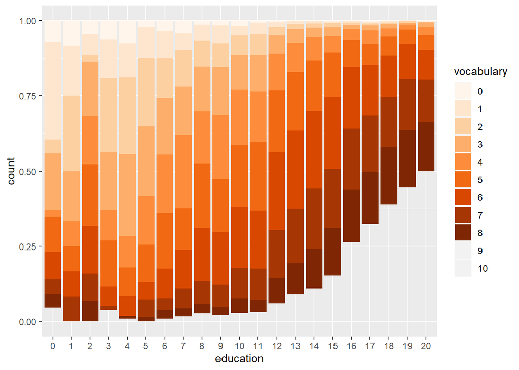

```r
ggplot(Vocab, aes(x = education, fill = vocabulary)) +
  geom_bar(position = 'fill') +
  scale_fill_brewer(palette="Oranges")
```

#### 4.2.3 boxplot

##### `geom_boxplot()` 함수 이용

- outlier.colour옵션을 활용하여 이상값을 색깔로 표현
- outlier.shape옵션을 활용하여 이상값을 모양으로 표현
- geom_jitter와 함께 사용하면 데이터의 분포를 확인 할 수 있음

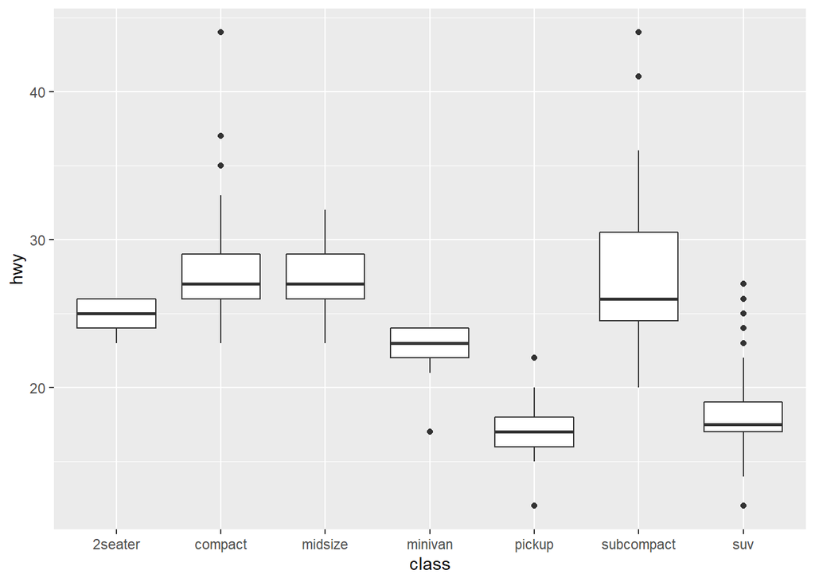

```r
p <- ggplot(mpg, aes(class, hwy))
p + geom_boxplot()
```

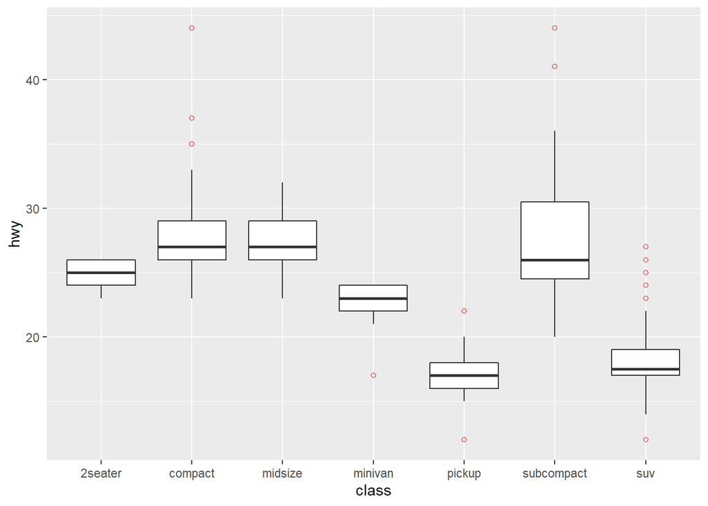

```r
p + geom_boxplot(outlier.colour = "red", outlier.shape = 1)
```

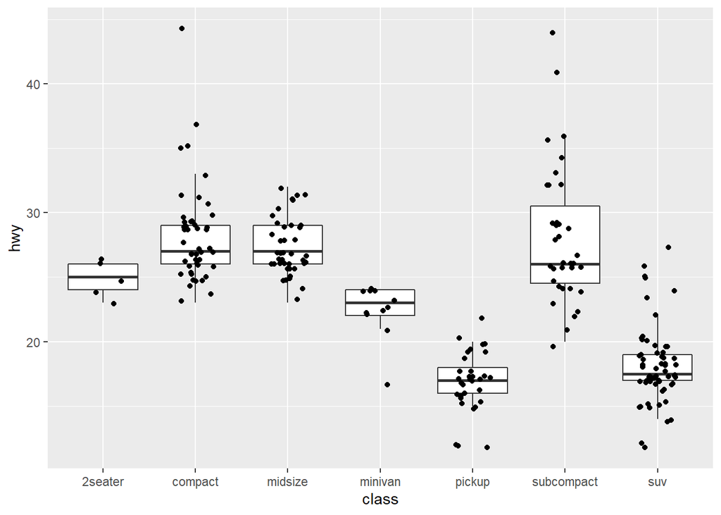

```r
p + geom_boxplot(outlier.shape = NA) + geom_jitter(width = 0.2)
```

- geom_dotplot() : 점으로 표현
- geom_violin() : 데이터의 부피를 두께로 표현

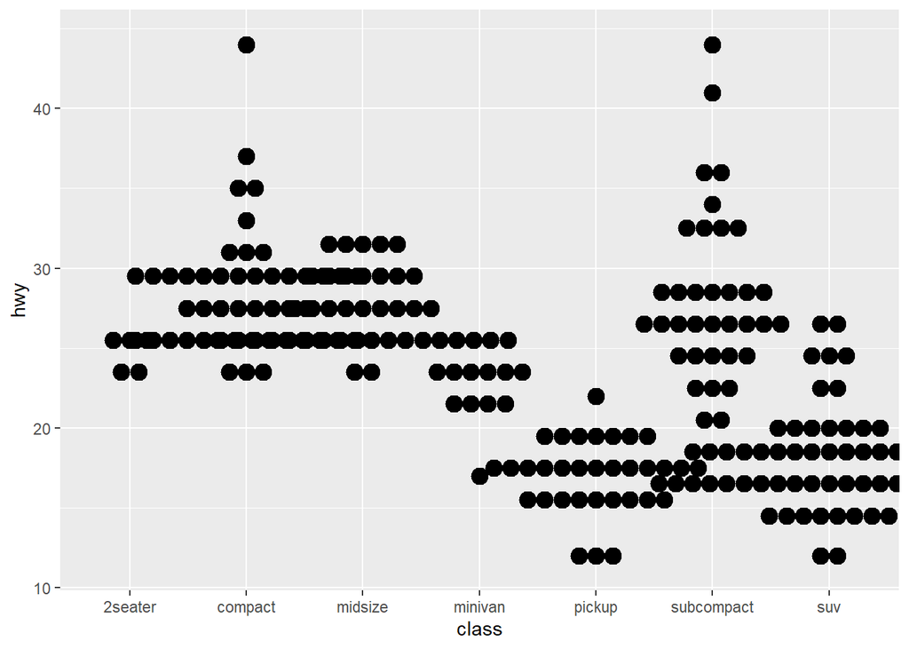

```r
f = ggplot(mpg,aes(class,hwy))
f + geom_dotplot(binaxis = "y",
                 stackdir = "center")
```

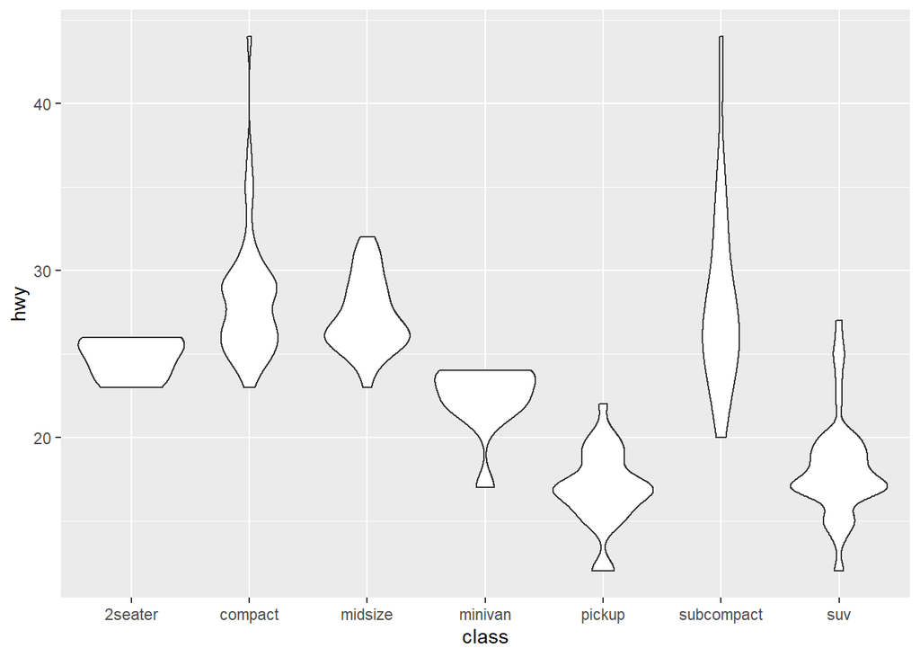

```r
f + geom_violin(scale="area")
```

#### 4.2.4 ggplot 예제

- 그래픽 문법은 다음의 7개 요소로 구성됨
- 1. Data: 시각화에 사용될 데이터
- 2. Aesthetics: 데이터를 나타내는 시각적인 요소(x축, y축, 사이즈, 색깔, 모양 등)
- 3. Geometrics: 데이터를 나타내는 도형
- 4. Facets: 하위 집합으로 분할하여 시각화
- 5. Statistics: 통계값을 표현
- 6. Coordinates: 데이터를 표현 할 이차원 좌표계
- 7. Theme: 그래프를 꾸밈

##### Data, Asethetics, Geometrics

- 3 Factor의 누적 수익률(로그 기준)을 구한 후, 이를 line으로 표현
- (1+r)=er이므로, 로그 수익률로 변환하기 위해 log (1+r)을 취함
- ggplot() 함수의 경우 %>%가 아닌 +로 연결됨
- Data: 누적 수익률 데이터를 사용, group 처리를 위해 long 형태로 변환
- Asethetics: x축에는 Date, y축에는 return, group 에는 factor 사용
- Geometrics: 선형 그래프 사용

```r
library(readr)
library(rvest)
library(dplyr)
df = read_csv("df.csv")
df_cum = df %>%
  select(Date, 2:4) %>%
  mutate_if(is.numeric, list(~log(1+.) %>% cumsum() ))

head(df_cum)
```

```
## # A tibble: 6 x 4
##   Date    `Mkt-RF`    SMB    HML
##   <chr>      <dbl>  <dbl>  <dbl>
## 1 1981-01  -0.0517 0.0296 0.0662
## 2 1981-02  -0.0460 0.0265 0.0758
## 3 1981-03  -0.0110 0.0616 0.0825
## 4 1981-04  -0.0324 0.105  0.105
## 5 1981-05  -0.0313 0.125  0.101
## 6 1981-06  -0.0552 0.116  0.151
```

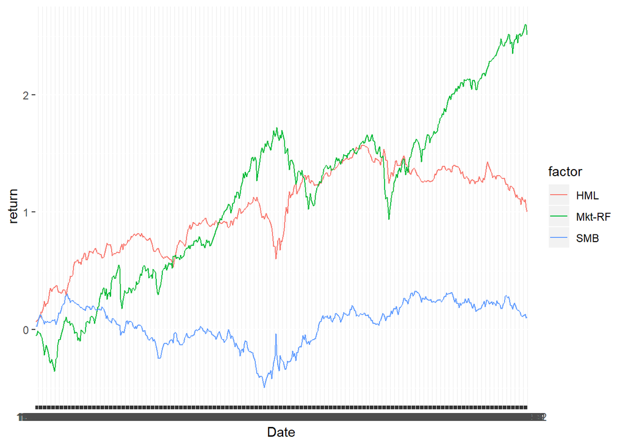

```r
library(tidyr)
library(ggplot2)
library(stringr)
df_cum %>%
  pivot_longer(cols = -Date, names_to = 'factor',
               values_to = 'return') %>%
  ggplot(aes(x = Date, y = return, group = factor)) +
  geom_line(aes(color = factor))
```

*기간이 짧을 때는 line과 함께 point를 같이 접목시켜 시각화 하는 것이 보기 좋음

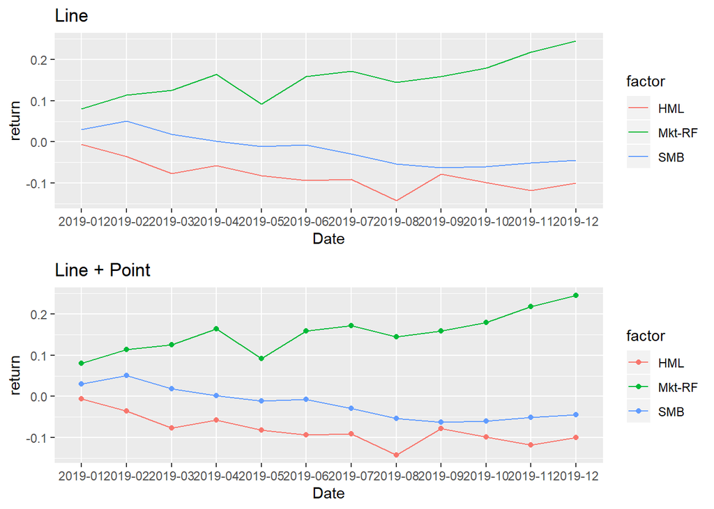

```r
p1 = df %>%
  filter(str_sub(Date, 1, 4) == '2019') %>%
  select(Date, 2:4) %>%
  mutate_if(is.numeric, list(~log(1+.) %>% cumsum() )) %>%
  pivot_longer(cols = -Date, names_to = 'factor',
               values_to = 'return') %>%
  ggplot(aes(x = Date, y = return, group = factor)) +
  geom_line(aes(color = factor)) +
  ggtitle('Line')

p2 = p1 + geom_point(aes(color = factor)) +ggtitle('Line + Point')

gridExtra::grid.arrange(p1, p2, ncol = 1)
```

##### Facets

- 각 팩터의 수익률을 따로 표현
- facet_grid() 혹은 facet_wrap() 함수 사용
- 물결 표시(~)를 통해 하위 집합으로 나누고자 하는 변수를 선택

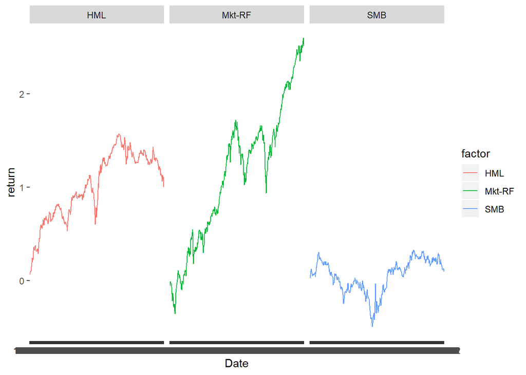

```r
df_cum %>%
  pivot_longer(cols = -Date, names_to = 'factor',
               values_to = 'return') %>%
  ggplot(aes(x = Date, y = return, group = factor)) +
  geom_line(aes(color = factor)) +
  facet_grid(~ factor)
```

##### Statistics

- stat_summary_*() 함수 통해서 통계값 표현 가능
- dplyr 패키지 이용해 통계값 계산한 후, ggplot으로 표현하는 것이 훨씬 편함
- MKT 팩터의 월별 수익률 비교

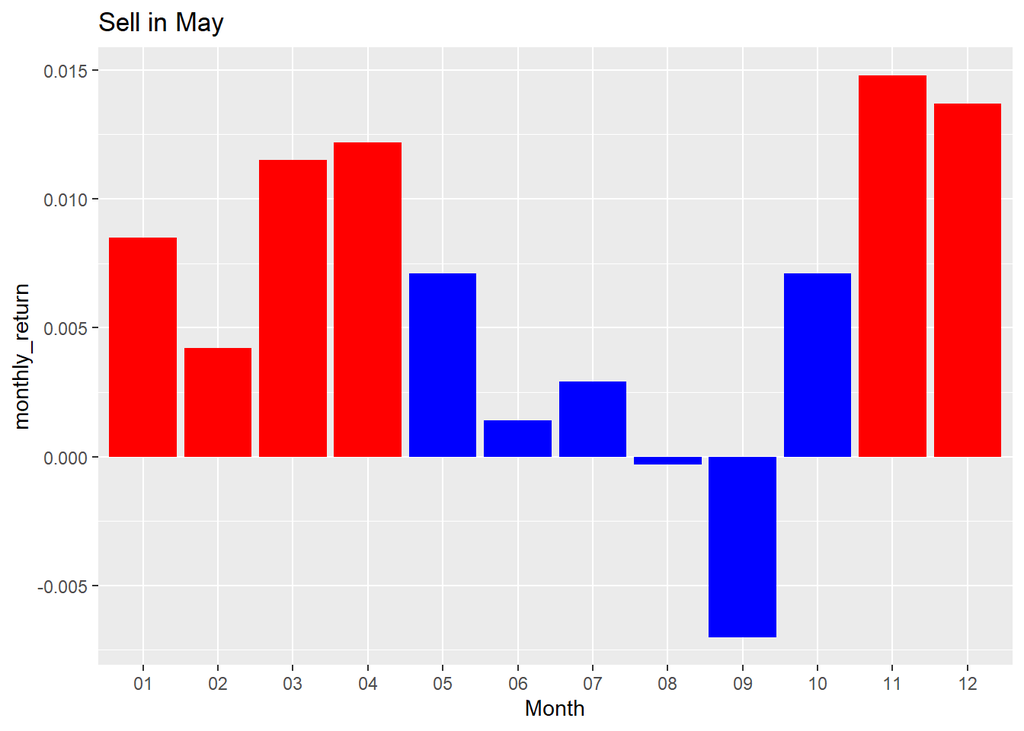

```r
df_m = df %>%
  select(Date, `Mkt-RF`) %>%
  separate(Date, c('Year', 'Month')) %>%
  group_by(Month) %>%
  summarize(monthly_return = mean(`Mkt-RF`) %>% round(., 4))

df_m %>%
  mutate(mycol = ifelse(Month %in% c('05', '06', '07', '08', '09', '10'),
                        'blue', 'red')) %>%
  ggplot(aes(x = Month, y = monthly_return)) +
  geom_col(aes(fill = mycol)) +
  scale_fill_identity() +
  ggtitle('Sell in May')
```

- MKT 팩터의 수익률 히스토그램 (정규분포 확인)

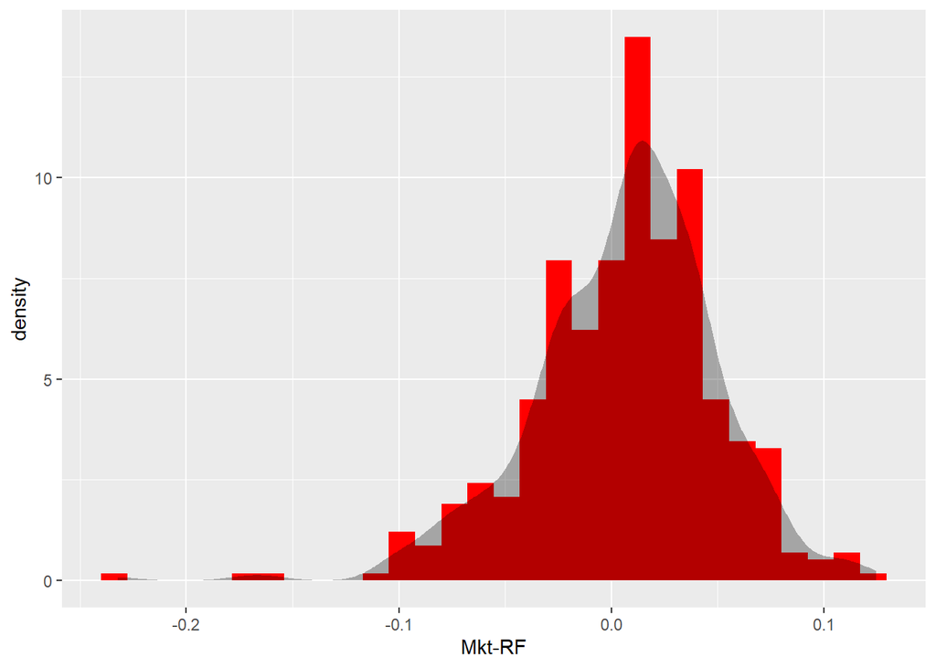

```r
df %>%
  select(Date, `Mkt-RF`) %>%
  ggplot(aes(x = `Mkt-RF`)) +
  geom_histogram(aes(y = ..density..), fill = 'red') +
  geom_density(color = NA, fill = 'black', alpha = 0.3)
```

##### Coordinates

- Coordinates는 좌표를 의미
- coord_*() 함수를 이용하여 x축 혹은 y축 정보를 변형할 수 있음
- coord_cartesian(): x축과 y축 범위 지정
- coord_flip(): x축과 y축 뒤집기

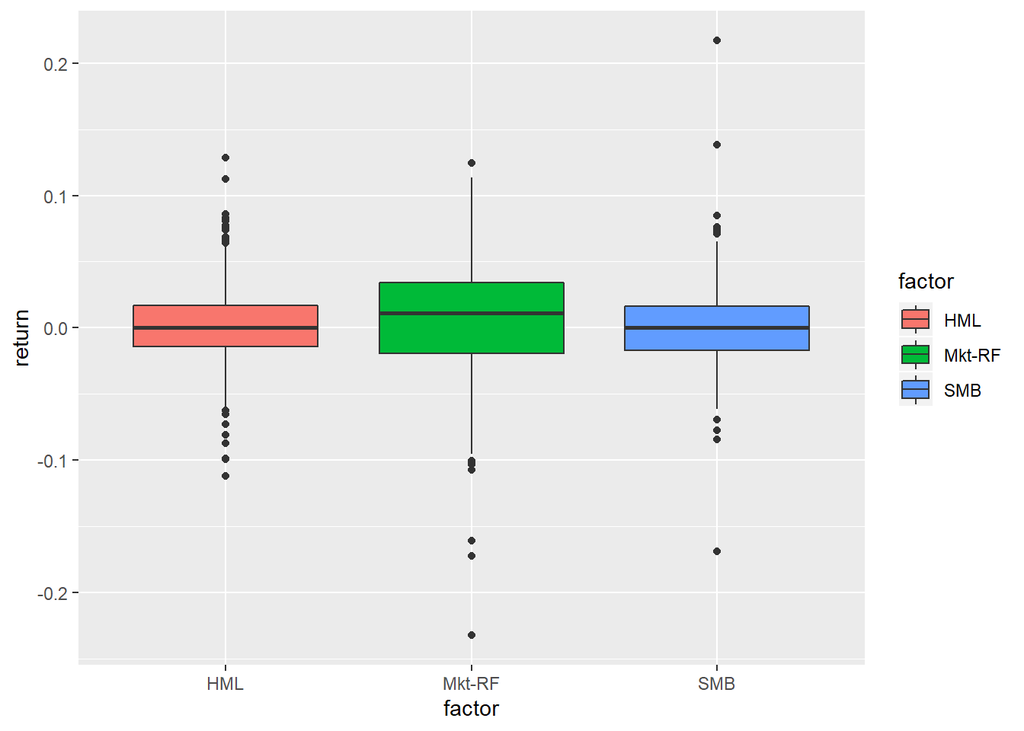

```r
df %>%
  select(1:4) %>%
  pivot_longer(cols = -Date, names_to = 'factor', values_to = 'return') %>%
  ggplot(aes(x = factor, y = return)) +
  geom_boxplot(aes(fill = factor))
```

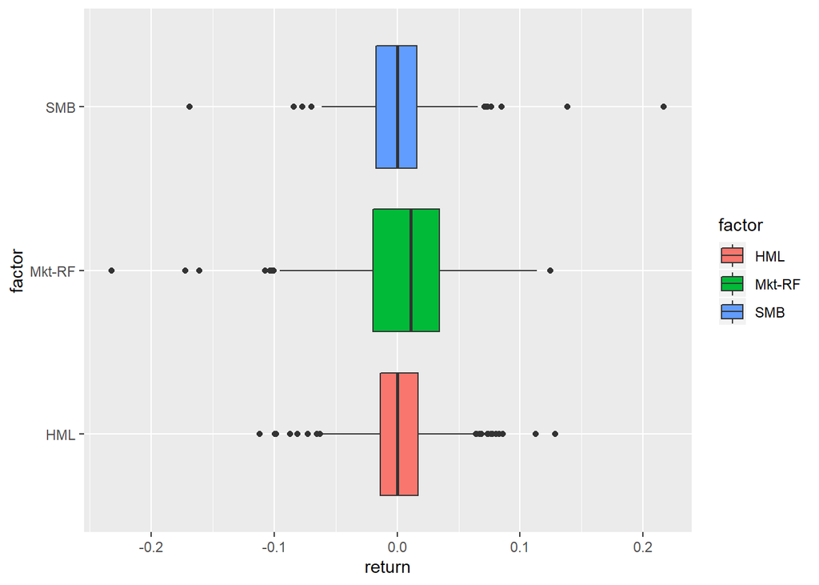

```r
df %>%
  select(1:4) %>%
  pivot_longer(cols = -Date, names_to = 'factor', values_to = 'return') %>%
  ggplot(aes(x = factor, y = return)) +
  geom_boxplot(aes(fill = factor)) +
  coord_flip()
```

##### Theme

- 그림의 제목, 축 제목, 축 단위, 범례, 디자인 등 그림을 꾸며주는 역할을 담당
- 누적 수익률 그래프를 꾸밈
- Date를 yyyy-mm-dd로 바꿔 Date 타입으로 변경
- factor 컬럼의 level을 변경(MKT, SMB, HML)
- 테마를 bw로 변경
- 범례를 밑으로 보내며, 범례 제목을 삭제
- x축 텍스트 기울기 변경
- 주, 보조 라인을 삭제
- xlab, ylab 문자 삭제

```r
library(zoo)
```

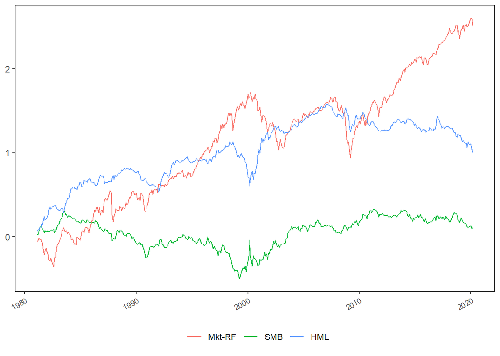

```r
df %>%
  select(Date, 2:4) %>%
  mutate_if(is.numeric, list(~log(1+.) %>% cumsum() )) %>%
  mutate(Date = as.Date(as.yearmon(Date, "%Y-%m"), frac = 1)) %>%
  pivot_longer(cols = -Date, names_to = 'factor',
               values_to = 'return') %>%
  mutate(factor = base::factor(factor,
                               levels = c('Mkt-RF', 'SMB', 'HML'))) %>%
  ggplot(aes(x = Date, y = return, group = factor)) +
  geom_line(aes(color = factor)) +
  theme_bw() +
  theme(
    legend.position = 'bottom',
    legend.title = element_blank(),
    panel.grid.major.x = element_blank(),
    panel.grid.minor.x = element_blank(),
    panel.grid.major.y = element_blank(),
    panel.grid.minor.y = element_blank(),
    axis.text.x = element_text(angle = 30, hjust = 1, size = 8)
  ) +
  xlab(NULL) +
  ylab(NULL)
```

### 4.3 ggplot의 확장 패키지

- ggplot을 응용한 다양한 확장 패키지가 존재
- http://www.ggplot2-exts.org/gallery/